# stage2_writeup

Evan Donch

## Topic and Motivation

This project focuses on understand what drives winning in the NBA. Specifically I examine how team performance statistics and payroll relate to winning percentage. My motivation behind this project is to explore whether spending more money actually leads to better outcomes, which on-court performance metrics are the most associated with winning.

## Data

I used two main datasets for this project:

-Team performance data from Basketball Reference

-Team Payroll data from HoopsHype

The team performance data includes statistics such as wins, losses, offensive rating, defensive rating, pace, and shooting efficiency. The payroll data includes total team salary for each season. The datasets cover all NBA teams of multiple seasons (2015-2024) and were merged using team name and season.

## Data Processing

The data required several cleaning steps before analysis. First the team statistics data was imported from CSV files and cleaned by removing non-team rows and converting variables to numberic format. Additional variables such as winning percentage were created. Second, the payroll data required more extensive cleaning because it was structured in an alternating row format. I separated team names and payroll values and combined them into a clean dataset. Finally, team names were standardized across both datasets to ensure consistency. The datasets were then merged into a single dataset where each row represents a team-season observation.

## Figure 1: Team Payroll and Winning Percentage

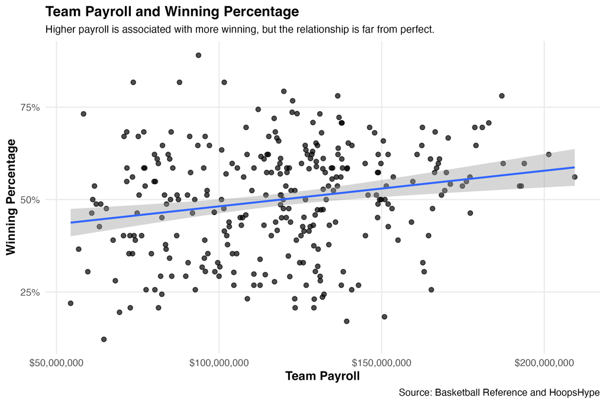

This figure examines the relationship between team payroll and winning percentage.

The purpose of this visualization is to evaluate whether higher spending leads to better team performance. A scatter plot with a fitted regression line was used to clearly show both individual team observations and the overall trend.

The results show a positive relationship between payroll and winning, but with significant variation. This suggests that while spending more may help, it does not guarantee success.

## Figure 2: Offensive Rating and Winning Percentage

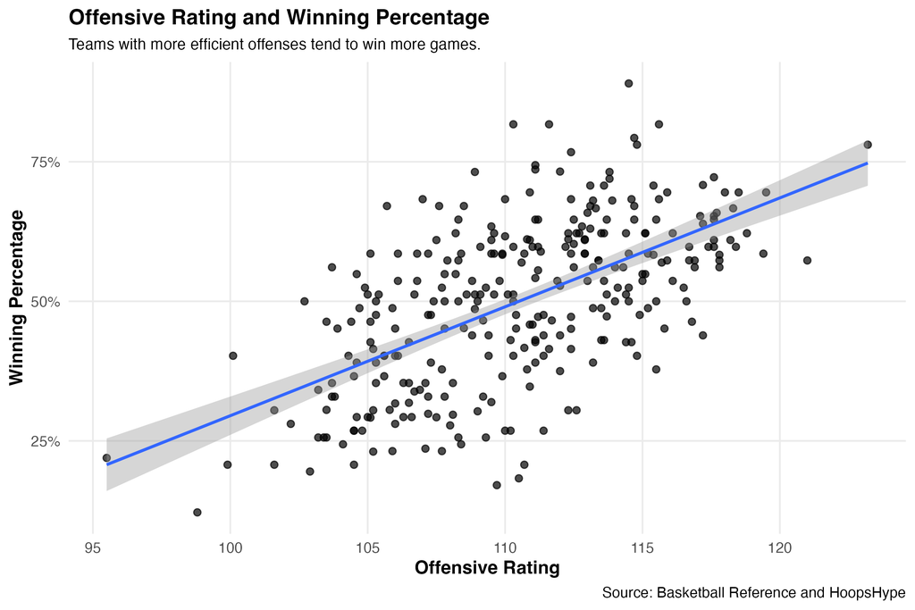

This figure shows the relationship between offensive rating and winning percentage.

The purpose is to evaluate whether offensive efficiency is a key driver of success. A scatter plot with a regression line highlights the strength of this relationship.

The visualization shows a strong positive relationship, indicating that teams with higher offensive efficiency tend to win more games.

## Figure 3: Defensive Rating and Winning Percentage

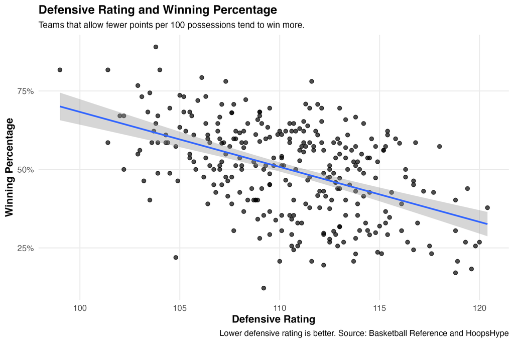

This figure examines the relationship between defensive rating and winning percentage.

The goal is to understand the role of defense in team success. Since lower defensive rating is better, the relationship is expected to be negative.

The plot shows that teams with better defense (lower defensive rating) tend to have higher winning percentages, reinforcing the importance of defense.

## Figure 4: Three-Point Attempt Rate and Winning Percentage

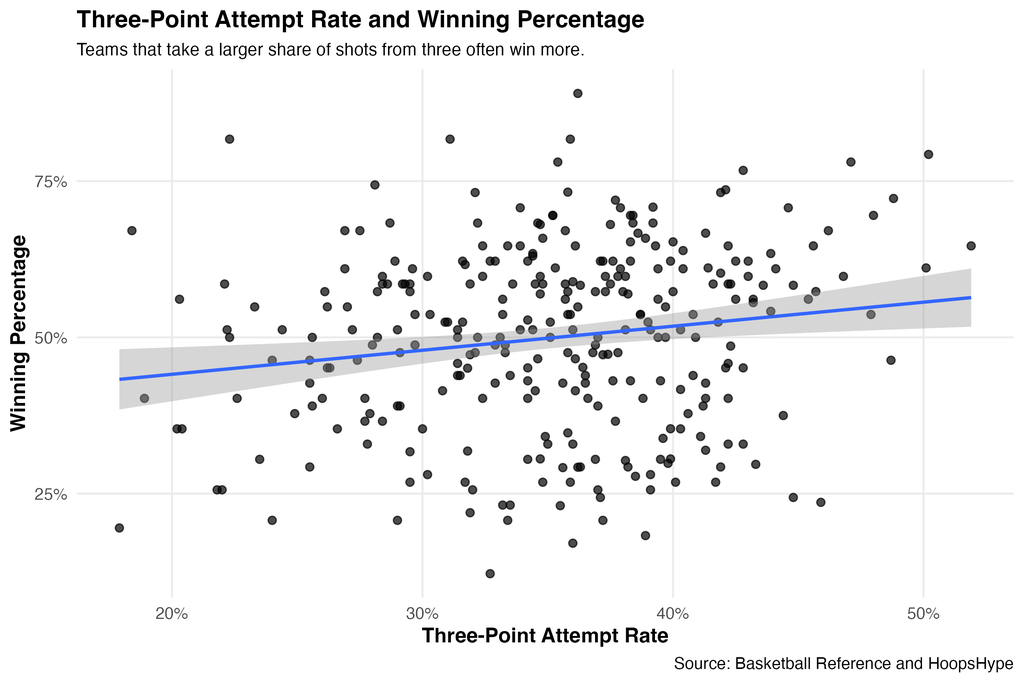

This figure explores how three-point shooting strategy relates to winning.

The purpose is to capture the impact of modern NBA trends, particularly the increased reliance on three-point shooting.

The results suggest that teams that take a higher proportion of three-point shots tend to perform better, although the relationship is not as strong as efficiency metrics.

## Figure 5: True Shooting Percentage and Winning Percentage

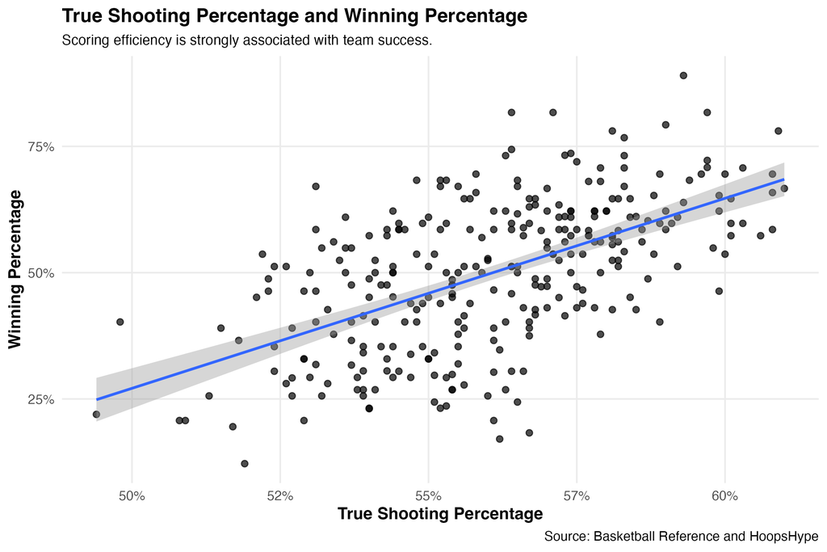

This figure analyzes the relationship between scoring efficiency and winning.

True shooting percentage is a comprehensive measure of scoring efficiency, making it useful for evaluating overall offensive performance.

The plot shows a strong positive relationship, suggesting that efficiency is one of the most important factors in determining team success.

## Figure 6: League Trend in Three-Point Attempt Rate

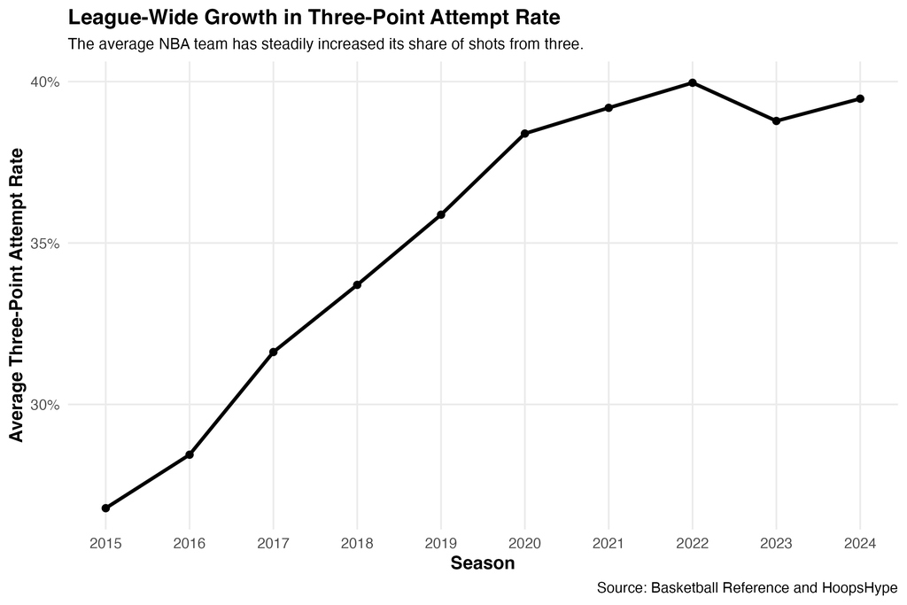

This figure shows how three-point attempt rates have changed over time across the NBA.

The purpose is to highlight how league strategy has evolved.

The upward trend clearly shows that teams have increasingly relied on three-point shooting over time, reflecting a major shift in how the game is played.